# Introduction to Phylogenetics in R

# An introduction to phylogenetic comparative methods in R

This tutorial is intended to get you familiar with the R environment for conducting phylogenetic comparative analyses.

## I. Preparing the R environment

### Installing packages

To install a package directly from CRAN, use:

```r
install.packages("geiger")
```

Load the package using ‘library’. These days, many packages may not be on CRAN, but instead hosted on github, bitbucket etc. To install these packages, it’s useful to use the `devtools` package.

```r
library(geiger)
library(devtools)
library(treeplyr)
```

For phylogenetic comparative methods, there are a number of packages available. One place to find them all is the ‘Phylogenetics Task View’ run by Brian O’meara: (http://cran.r-project.org/web/views/Phylogenetics.html) All of these packages can be installed at once using the following lines (however, please note that this process can take a considerable amount of time)

```r
install.packages("ctv")
install.views("Phylogenetics")
```

### Directory management

R looks for files in the ‘working directory’.

```r
getwd()
```

```
## [1] "/home/juyeda/repos/Intro2PCMs/R"
```

```r
dir.create("~/repos/Intro2PCMs/")
dir.create("~/repos/Intro2PCMs//R")
dir.create("~/repos/Intro2PCMs//data")
dir.create("~/repos/Intro2PCMs//output")
```

```r
setwd("~/repos/Intro2PCMs/R/")
```

Save this script into the folder ‘./R’ and place your data files into the directory ‘./data’ Now we are ready to read in data and tree files.

### II. Reading in a tree & tree data structures

There are a number of functions to read in phylogenetic tree data into R. We are going to use as our example tree phylogeny of Muroid rodents (Schenk, Rowe & Steppan, 2013; Systematic Biology). The tree can be downloaded from my github site, or it be accessed directly from treebase (submission 12303).

```r
tree <- read.tree("../data/schenk.tre")
tree
```

```
##
## Phylogenetic tree with 305 tips and 304 internal nodes.
##
## Tip labels:
##  Eliomys_quercinus, Sciurus_sp., Sicista_tianshanica, Napaeozapus_insignis, Zapus_princeps, Allactaga_sibirica, ...
##
## Rooted; includes branch lengths.
```

We can plot the tree:

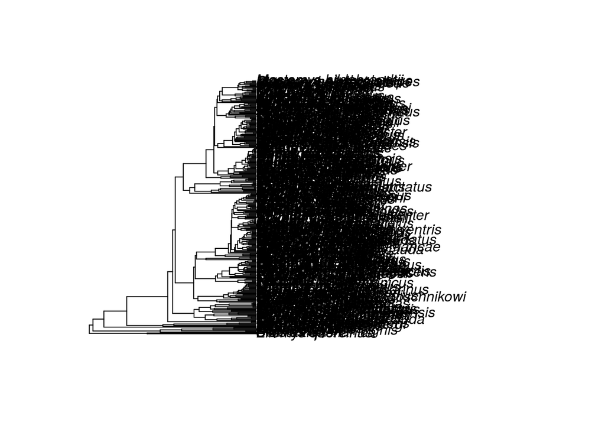

```r
plot(tree)
```

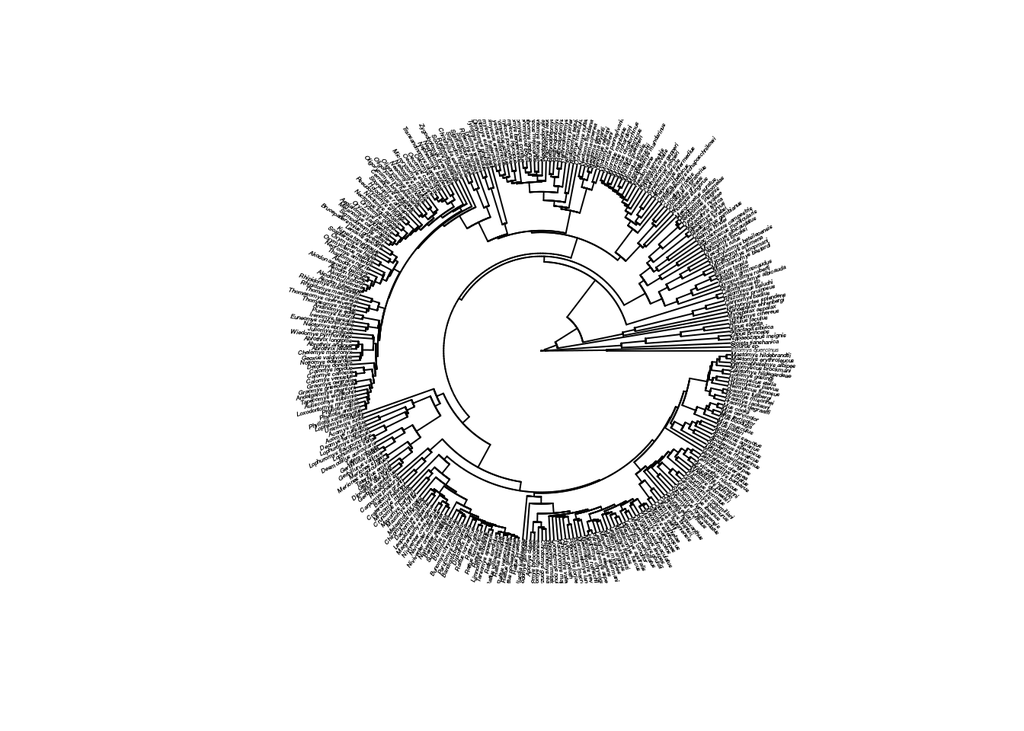

```r
plot(tree, type="fan", cex=0.25)
```

You may notice that the help file for `plot` is not very helpful for options for phylogenies:

```r
?plot
```

This is because `plot` is a “method” that behaves differently on objects of different classes.

```r
plot
```

```
## function (x, y, ...)
## UseMethod("plot")
## <bytecode: 0x28c9d50>
## <environment: namespace:graphics>
```

```r
methods(plot)
```

```
##  [1] plot.aareg*            plot.acf*              plot.ACF*
##  [4] plot.anc.Bayes*        plot.ancThresh*        plot.augPred*
##  [7] plot.auteurMCMC*       plot.auteurMCMCMC*     plot.backbonePhylo*
## [10] plot.changesMap*       plot.cohesiveBlocks*   plot.communities*
## [13] plot.compareFits*      plot.contMap*          plot.cophylo*
## [16] plot.correlogram       plot.correlogramList   plot.correspondence*
## [19] plot.cospeciation*     plot.cox.zph*          plot.data.frame*
## [22] plot.decomposed.ts*    plot.default           plot.dendrite*
## [25] plot.dendrogram*       plot.density*          plot.densityMap*
## [28] plot.describe.simmap*  plot.deSolve*          plot.ecdf
## [31] plot.evonet            plot.expand.clade*     plot.factor*
## [34] plot.fitBayes*         plot.fitMk*            plot.fitPagel*
## [37] plot.formula*          plot.function          plot.gfit*
## [40] plot.gls*              plot.hclust*           plot.histogram*
## [43] plot.HoltWinters*      plot.igraph*           plot.intervals.lmList*
## [46] plot.isoreg*           plot.lda*              plot.lm*
## [49] plot.lme*              plot.lmList*
##  [ reached getOption("max.print") -- omitted 66 entries ]
## see '?methods' for accessing help and source code
```

```r
class(tree)
```

```
## [1] "phylo"
```

```r
?plot.phylo
```

How is a tree stored? How can it be manipulated and modified? A tree object in R is a data structure called a “list”, and given a special class, called a “phylo” object. It will be worth your time getting familiar with [data structures in R](http://adv-r.had.co.nz/Data-structures.html).

`str` is a useful commands for determining what is in an R object:

```r
str(tree)
```

```
## List of 4
##  $ edge       : int [1:608, 1:2] 306 307 307 306 308 309 309 310 311 311 ...
##  $ edge.length: num [1:608] 16.45 30.95 30.95 1.04 19.12 ...
##  $ Nnode      : int 304
##  $ tip.label  : chr [1:305] "Eliomys_quercinus" "Sciurus_sp." "Sicista_tianshanica" "Napaeozapus_insignis" ...
##  - attr(*, "class")= chr "phylo"
##  - attr(*, "order")= chr "cladewise"
```

Each element of the list can be accessed by multiple means:

```r
tree['tip.label']
```

```
## $tip.label
##  [1] "Eliomys_quercinus"            "Sciurus_sp."
##  [3] "Sicista_tianshanica"          "Napaeozapus_insignis"
##  [5] "Zapus_princeps"               "Allactaga_sibirica"
##  [7] "Dipus_sagitta"                "Jaculus_jaculus"
##  [9] "Typhlomys_cinereus"           "Myospalax_aspalax"
## [11] "Nanospalax_ehrenbergi"        "Tachyoryctes_splendens"
## [13] "Cannomys_badius"              "Rhizomys_pruinosus"
## [15] "Calomyscus_baluchi"           "Calomyscus_sp"
## [17] "Brachytarsomys_albicauda"     "Gymnuromys_roberti"
## [19] "Voalavo_gymnocaudus"          "Eliurus_minor"
## [21] "Eliurus_tanala"               "Macrotarsomys_bastardi"
## [23] "Monticolomys_koopmani"        "Hypogeomys_antimena"
## [25] "Brachyuromys_betsileoensis"   "Nesomys_rufus"
## [27] "Delanymys_brooksi"            "Mystromys_albicaudatus"
## [29] "Petromyscus_monticularis"     "Saccostomus_campestris"
## [31] "Beamys_hindei"                "Cricetomys_gambianus"
## [33] "Steatomys_krebsi"             "Steatomys_parvus"
## [35] "Malacothrix_typica"           "Dendromus_nyasae"
## [37] "Dendromus_insignis"           "Dendromus_mesomelas"
## [39] "Mesocricetus_auratus"         "Phodopus_sungorus"
## [41] "Cricetulus_griseus"           "Cricetulus_migratorius"
## [43] "Cricetus_cricetus"            "Prometheomys_schaposchnikowi"
## [45] "Ondatra_zibethicus"           "Phenacomys_intermedius"
## [47] "Lemmus_sibiricus"             "Synaptomys_cooperi"
## [49] "Clethrionomys_gapperi"        "Chionomys_nivalis"
##  [ reached getOption("max.print") -- omitted 255 entries ]
```

```r
tree[['tip.label']]
```

```
##  [1] "Eliomys_quercinus"            "Sciurus_sp."
##  [3] "Sicista_tianshanica"          "Napaeozapus_insignis"
##  [5] "Zapus_princeps"               "Allactaga_sibirica"
##  [7] "Dipus_sagitta"                "Jaculus_jaculus"
##  [9] "Typhlomys_cinereus"           "Myospalax_aspalax"
## [11] "Nanospalax_ehrenbergi"        "Tachyoryctes_splendens"
## [13] "Cannomys_badius"              "Rhizomys_pruinosus"
## [15] "Calomyscus_baluchi"           "Calomyscus_sp"
## [17] "Brachytarsomys_albicauda"     "Gymnuromys_roberti"
## [19] "Voalavo_gymnocaudus"          "Eliurus_minor"
## [21] "Eliurus_tanala"               "Macrotarsomys_bastardi"
## [23] "Monticolomys_koopmani"        "Hypogeomys_antimena"
## [25] "Brachyuromys_betsileoensis"   "Nesomys_rufus"
## [27] "Delanymys_brooksi"            "Mystromys_albicaudatus"
## [29] "Petromyscus_monticularis"     "Saccostomus_campestris"
## [31] "Beamys_hindei"                "Cricetomys_gambianus"
## [33] "Steatomys_krebsi"             "Steatomys_parvus"
## [35] "Malacothrix_typica"           "Dendromus_nyasae"
## [37] "Dendromus_insignis"           "Dendromus_mesomelas"
## [39] "Mesocricetus_auratus"         "Phodopus_sungorus"
## [41] "Cricetulus_griseus"           "Cricetulus_migratorius"
## [43] "Cricetus_cricetus"            "Prometheomys_schaposchnikowi"
## [45] "Ondatra_zibethicus"           "Phenacomys_intermedius"
## [47] "Lemmus_sibiricus"             "Synaptomys_cooperi"
## [49] "Clethrionomys_gapperi"        "Chionomys_nivalis"
##  [ reached getOption("max.print") -- omitted 255 entries ]
```

```r
tree[[3]]
```

```
## [1] 304
```

```r
tree$tip.label
```

```
##  [1] "Eliomys_quercinus"            "Sciurus_sp."
##  [3] "Sicista_tianshanica"          "Napaeozapus_insignis"
##  [5] "Zapus_princeps"               "Allactaga_sibirica"
##  [7] "Dipus_sagitta"                "Jaculus_jaculus"
##  [9] "Typhlomys_cinereus"           "Myospalax_aspalax"
## [11] "Nanospalax_ehrenbergi"        "Tachyoryctes_splendens"
## [13] "Cannomys_badius"              "Rhizomys_pruinosus"
## [15] "Calomyscus_baluchi"           "Calomyscus_sp"
## [17] "Brachytarsomys_albicauda"     "Gymnuromys_roberti"
## [19] "Voalavo_gymnocaudus"          "Eliurus_minor"
## [21] "Eliurus_tanala"               "Macrotarsomys_bastardi"
## [23] "Monticolomys_koopmani"        "Hypogeomys_antimena"
## [25] "Brachyuromys_betsileoensis"   "Nesomys_rufus"
## [27] "Delanymys_brooksi"            "Mystromys_albicaudatus"
## [29] "Petromyscus_monticularis"     "Saccostomus_campestris"
## [31] "Beamys_hindei"                "Cricetomys_gambianus"
## [33] "Steatomys_krebsi"             "Steatomys_parvus"
## [35] "Malacothrix_typica"           "Dendromus_nyasae"
## [37] "Dendromus_insignis"           "Dendromus_mesomelas"
## [39] "Mesocricetus_auratus"         "Phodopus_sungorus"
## [41] "Cricetulus_griseus"           "Cricetulus_migratorius"
## [43] "Cricetus_cricetus"            "Prometheomys_schaposchnikowi"
## [45] "Ondatra_zibethicus"           "Phenacomys_intermedius"
## [47] "Lemmus_sibiricus"             "Synaptomys_cooperi"
## [49] "Clethrionomys_gapperi"        "Chionomys_nivalis"
##  [ reached getOption("max.print") -- omitted 255 entries ]
```

The structure of the tree is stored in the edge matrix:

```r
tree$edge
```

```
##        [,1] [,2]
##   [1,]  306  307
##   [2,]  307    1
##   [3,]  307    2
##   [4,]  306  308
##   [5,]  308  309
##   [6,]  309    3
##   [7,]  309  310
##   [8,]  310  311
##   [9,]  311    4
##  [10,]  311    5
##  [11,]  310  312
##  [12,]  312    6
##  [13,]  312  313
##  [14,]  313    7
##  [15,]  313    8
##  [16,]  308  314
##  [17,]  314    9
##  [18,]  314  315
##  [19,]  315  316
##  [20,]  316   10
##  [21,]  316  317
##  [22,]  317   11
##  [23,]  317  318
##  [24,]  318   12
##  [25,]  318  319
##  [ reached getOption("max.print") -- omitted 583 rows ]
```

And branch lengths are stored in the list element `edge.length`

```r
tree$edge.length
```

```
##  [1] 16.454920 30.951218 30.951218  1.036558 19.122934 27.246646  6.098144
##  [8] 18.255843  2.892659  2.892659  8.926983 12.221519  5.945134  6.276385
## [15]  6.276385  3.101443 43.268137  6.507266 10.276527 26.484344  3.141303
## [22] 23.343042 15.076585  8.266457  3.502364  4.764093  4.764093 11.663253
## [29] 23.784354  1.313264  1.313264  1.392402  6.091229  3.173725  3.347564
## [36] 11.092697  4.133406  6.959292  1.505509  5.453783  4.094128  1.359655
## [43]  1.359655  2.496259  9.647273  2.296729  2.296729  4.258825  7.685177
## [50]  2.595582
##  [ reached getOption("max.print") -- omitted 558 entries ]
```

Tips can be dropped with the function `drop.tip`:

```r
#tree before:
tree
```

```
##
## Phylogenetic tree with 305 tips and 304 internal nodes.
##
## Tip labels:
##  Eliomys_quercinus, Sciurus_sp., Sicista_tianshanica, Napaeozapus_insignis, Zapus_princeps, Allactaga_sibirica, ...
##
## Rooted; includes branch lengths.
```

```r
#tree after dropping two species:
drop.tip(tree, c("Eliomys_quercinus", "Sicista_tianshanica"))
```

```
##
## Phylogenetic tree with 303 tips and 302 internal nodes.
##
## Tip labels:
##  Sciurus_sp., Napaeozapus_insignis, Zapus_princeps, Allactaga_sibirica, Dipus_sagitta, Jaculus_jaculus, ...
##
## Rooted; includes branch lengths.
```

We can get a distance matrix from the tree as follows:

```r
dist <- cophenetic(tree)
dist[1:5,1:5]
```

```
##                      Eliomys_quercinus Sciurus_sp. Sicista_tianshanica
## Eliomys_quercinus              0.00000    61.90244            94.81228
## Sciurus_sp.                   61.90244     0.00000            94.81228
## Sicista_tianshanica           94.81228    94.81228             0.00000
## Napaeozapus_insignis          94.81228    94.81228            54.49329
## Zapus_princeps                94.81228    94.81228            54.49329
##                      Napaeozapus_insignis Zapus_princeps
## Eliomys_quercinus               94.812276      94.812276
## Sciurus_sp.                     94.812276      94.812276
## Sicista_tianshanica             54.493291      54.493291
## Napaeozapus_insignis             0.000000       5.785318
## Zapus_princeps                   5.785318       0.000000
```

### III. Matching a tree with a dataset

```r
pantheria <- read.table("http://www.esapubs.org/archive/ecol/E090/184/PanTHERIA_1-0_WR05_Aug2008.txt",header=TRUE,sep="\t")
rownames(pantheria) <- gsub(" ", "_", pantheria$MSW05_Binomial)
head(pantheria)
```

|  | MSW05_Order | MSW05_Family | MSW05_Genus | MSW05_Species | MSW05_Binomial | X1.1_ActivityCycle | X5.1_AdultBodyMass_g | X8.1_AdultForearmLen_mm | X13.1_AdultHeadBodyLen_mm | X2.1_AgeatEyeOpening_d | X3.1_AgeatFirstBirth_d | X18.1_BasalMetRate_mLO2hr | X5.2_BasalMetRateMass_g | X6.1_DietBreadth | X7.1_DispersalAge_d | X9.1_GestationLen_d | X12.1_HabitatBreadth | X22.1_HomeRange_km2 | X22.2_HomeRange_Indiv_km2 | X14.1_InterbirthInterval_d | X15.1_LitterSize | X16.1_LittersPerYear | X17.1_MaxLongevity_m | X5.3_NeonateBodyMass_g | X13.2_NeonateHeadBodyLen_mm | X21.1_PopulationDensity_n.km2 | X10.1_PopulationGrpSize | X23.1_SexualMaturityAge_d | X10.2_SocialGrpSize | … |
| --- | --- | --- | --- | --- | --- | --- | --- | --- | --- | --- | --- | --- | --- | --- | --- | --- | --- | --- | --- | --- | --- | --- | --- | --- | --- | --- | --- | --- | --- | --- |
| Camelus_dromedarius | Artiodactyla | Camelidae | Camelus | dromedarius | Camelus dromedarius | 3 | 492714.47 | -999 | -999.00 | -999.00 | 1651.62 | 40293.0 | 407000 | 3 | -999.00 | 386.51 | 1 | 196.32 | -999.00 | 614.41 | 0.98 | 1 | 480.0 | 36751.19 | -999 | 0.98 | 11 | 1947.94 | 10 | … |
| Canis_adustus | Carnivora | Canidae | Canis | adustus | Canis adustus | 1 | 10392.49 | -999 | 745.32 | -999.00 | -999.00 | -999.0 | -999 | 6 | 329.99 | 65.00 | 1 | 1.01 | 1.01 | -999.00 | 4.50 | -999 | 137.0 | -999.00 | -999 | 0.74 | -999 | 249.88 | -999 | … |
| Canis_aureus | Carnivora | Canidae | Canis | aureus | Canis aureus | 2 | 9658.70 | -999 | 827.53 | 7.50 | -999.00 | -999.0 | -999 | 6 | -999.00 | 61.24 | 1 | 2.95 | 3.13 | 365.00 | 3.74 | -999 | 192.0 | 211.82 | -999 | 0.22 | -999 | 371.23 | -999 | … |
| Canis_latrans | Carnivora | Canidae | Canis | latrans | Canis latrans | 2 | 11989.10 | -999 | 872.39 | 11.94 | 365.00 | 3699.0 | 10450 | 1 | 255.00 | 61.74 | 1 | 18.88 | 19.91 | 365.00 | 5.72 | -999 | 262.0 | 200.01 | -999 | 0.25 | -999 | 372.90 | -999 | … |
| Canis_lupus | Carnivora | Canidae | Canis | lupus | Canis lupus | 2 | 31756.51 | -999 | 1055.00 | 14.01 | 547.50 | 11254.2 | 33100 | 1 | 180.00 | 63.50 | 1 | 159.86 | 43.13 | 365.00 | 4.98 | 2 | 354.0 | 412.31 | -999 | 0.01 | -999 | 679.37 | -999 | … |
| Bos_frontalis | Artiodactyla | Bovidae | Bos | frontalis | Bos frontalis | 2 | 800143.05 | -999 | 2700.00 | -999.00 | -999.00 | -999.0 | -999 | 3 | -999.00 | 273.75 | -999 | -999.00 | -999.00 | 403.02 | 1.22 | 1 | 314.4 | 22977.05 | -999 | 0.54 | -999 | 610.97 | 40 | … |

```r
td <- make.treedata(tree, pantheria)
td
```

```
## $phy
##
## Phylogenetic tree with 282 tips and 281 internal nodes.
##
## Tip labels:
##  Eliomys_quercinus, Sicista_tianshanica, Napaeozapus_insignis, Zapus_princeps, Allactaga_sibirica, Dipus_sagitta, ...
##
## Rooted; includes branch lengths.
##
## $dat
## # A tibble: 282 x 55
##    MSW05_Order MSW05_Family    MSW05_Genus MSW05_Species MSW05_Binomial
##    <fct>       <fct>           <fct>       <fct>         <fct>
##  1 Rodentia    Gliridae        Eliomys     quercinus     Eliomys quercinus
##  2 Rodentia    Dipodidae       Sicista     tianshanica   Sicista tianshan…
##  3 Rodentia    Dipodidae       Napaeozapus insignis      Napaeozapus insi…
##  4 Rodentia    Dipodidae       Zapus       princeps      Zapus princeps
##  5 Rodentia    Dipodidae       Allactaga   sibirica      Allactaga sibiri…
##  6 Rodentia    Dipodidae       Dipus       sagitta       Dipus sagitta
##  7 Rodentia    Dipodidae       Jaculus     jaculus       Jaculus jaculus
##  8 Rodentia    Platacanthomyi… Typhlomys   cinereus      Typhlomys cinere…
##  9 Rodentia    Spalacidae      Myospalax   aspalax       Myospalax aspalax
## 10 Rodentia    Spalacidae      Tachyoryct… splendens     Tachyoryctes spl…
## # ... with 272 more rows, and 50 more variables: X1.1_ActivityCycle <int>,
## #   X5.1_AdultBodyMass_g <dbl>, X8.1_AdultForearmLen_mm <dbl>,
## #   X13.1_AdultHeadBodyLen_mm <dbl>, X2.1_AgeatEyeOpening_d <dbl>,
## #   X3.1_AgeatFirstBirth_d <dbl>, X18.1_BasalMetRate_mLO2hr <dbl>,
## #   X5.2_BasalMetRateMass_g <dbl>, X6.1_DietBreadth <int>,
## #   X7.1_DispersalAge_d <dbl>, X9.1_GestationLen_d <dbl>,
## #   X12.1_HabitatBreadth <int>, X22.1_HomeRange_km2 <dbl>,
## #   X22.2_HomeRange_Indiv_km2 <dbl>, X14.1_InterbirthInterval_d <dbl>,
## #   X15.1_LitterSize <dbl>, X16.1_LittersPerYear <dbl>,
## #   X17.1_MaxLongevity_m <dbl>, X5.3_NeonateBodyMass_g <dbl>,
## #   X13.2_NeonateHeadBodyLen_mm <dbl>,
## #   X21.1_PopulationDensity_n.km2 <dbl>, X10.1_PopulationGrpSize <dbl>,
## #   X23.1_SexualMaturityAge_d <dbl>, X10.2_SocialGrpSize <dbl>,
## #   X24.1_TeatNumber <int>, X12.2_Terrestriality <int>,
## #   X6.2_TrophicLevel <int>, X25.1_WeaningAge_d <dbl>,
## #   X5.4_WeaningBodyMass_g <dbl>, X13.3_WeaningHeadBodyLen_mm <dbl>,
## #   References <fct>, X5.5_AdultBodyMass_g_EXT <dbl>,
## #   X16.2_LittersPerYear_EXT <dbl>, X5.6_NeonateBodyMass_g_EXT <dbl>,
## #   X5.7_WeaningBodyMass_g_EXT <dbl>, X26.1_GR_Area_km2 <dbl>,
## #   X26.2_GR_MaxLat_dd <dbl>, X26.3_GR_MinLat_dd <dbl>,
## #   X26.4_GR_MidRangeLat_dd <dbl>, X26.5_GR_MaxLong_dd <dbl>,
## #   X26.6_GR_MinLong_dd <dbl>, X26.7_GR_MidRangeLong_dd <dbl>,
## #   X27.1_HuPopDen_Min_n.km2 <int>, X27.2_HuPopDen_Mean_n.km2 <dbl>,
## #   X27.3_HuPopDen_5p_n.km2 <dbl>, X27.4_HuPopDen_Change <dbl>,
## #   X28.1_Precip_Mean_mm <dbl>, X28.2_Temp_Mean_01degC <dbl>,
## #   X30.1_AET_Mean_mm <dbl>, X30.2_PET_Mean_mm <dbl>
```

```r
attributes(td)$dropped
```

```
## $dropped_from_tree
##  [1] "Camelus_dromedarius"     "Canis_adustus"
##  [3] "Canis_aureus"            "Canis_latrans"
##  [5] "Canis_lupus"             "Bos_frontalis"
##  [7] "Bos_grunniens"           "Bos_javanicus"
##  [9] "Callicebus_cupreus"      "Callicebus_discolor"
## [11] "Callicebus_donacophilus" "Callicebus_dubius"
## [13] "Callicebus_hoffmannsi"   "Callicebus_lucifer"
## [15] "Callicebus_lugens"       "Callicebus_medemi"
## [17] "Callicebus_melanochir"   "Callicebus_modestus"
## [19] "Caluromys_derbianus"     "Caluromys_lanatus"
## [21] "Caluromys_philander"     "Caluromysiops_irrupta"
## [23] "Calyptophractus_retusus" "Camelus_bactrianus"
## [25] "Bos_sauveli"             "Bos_taurus"
## [27] "Boselaphus_tragocamelus" "Brachiones_przewalskii"
```

[output cut: 26 more lines]

```r
colnames(td$dat)
```

```
##  [1] "MSW05_Order"                   "MSW05_Family"
##  [3] "MSW05_Genus"                   "MSW05_Species"
##  [5] "MSW05_Binomial"                "X1.1_ActivityCycle"
##  [7] "X5.1_AdultBodyMass_g"          "X8.1_AdultForearmLen_mm"
##  [9] "X13.1_AdultHeadBodyLen_mm"     "X2.1_AgeatEyeOpening_d"
## [11] "X3.1_AgeatFirstBirth_d"        "X18.1_BasalMetRate_mLO2hr"
## [13] "X5.2_BasalMetRateMass_g"       "X6.1_DietBreadth"
## [15] "X7.1_DispersalAge_d"           "X9.1_GestationLen_d"
## [17] "X12.1_HabitatBreadth"          "X22.1_HomeRange_km2"
## [19] "X22.2_HomeRange_Indiv_km2"     "X14.1_InterbirthInterval_d"
## [21] "X15.1_LitterSize"              "X16.1_LittersPerYear"
## [23] "X17.1_MaxLongevity_m"          "X5.3_NeonateBodyMass_g"
## [25] "X13.2_NeonateHeadBodyLen_mm"   "X21.1_PopulationDensity_n.km2"
## [27] "X10.1_PopulationGrpSize"       "X23.1_SexualMaturityAge_d"
## [29] "X10.2_SocialGrpSize"           "X24.1_TeatNumber"
## [31] "X12.2_Terrestriality"          "X6.2_TrophicLevel"
## [33] "X25.1_WeaningAge_d"            "X5.4_WeaningBodyMass_g"
## [35] "X13.3_WeaningHeadBodyLen_mm"   "References"
## [37] "X5.5_AdultBodyMass_g_EXT"      "X16.2_LittersPerYear_EXT"
## [39] "X5.6_NeonateBodyMass_g_EXT"    "X5.7_WeaningBodyMass_g_EXT"
## [41] "X26.1_GR_Area_km2"             "X26.2_GR_MaxLat_dd"
## [43] "X26.3_GR_MinLat_dd"            "X26.4_GR_MidRangeLat_dd"
## [45] "X26.5_GR_MaxLong_dd"           "X26.6_GR_MinLong_dd"
## [47] "X26.7_GR_MidRangeLong_dd"      "X27.1_HuPopDen_Min_n.km2"
## [49] "X27.2_HuPopDen_Mean_n.km2"     "X27.3_HuPopDen_5p_n.km2"
##  [ reached getOption("max.print") -- omitted 5 entries ]
```

```r
td2 <- mutate(td, lnMass = log(X5.1_AdultBodyMass_g),lnBMR = log(X18.1_BasalMetRate_mLO2hr), desert=ifelse(X28.1_Precip_Mean_mm < 21, 1, 0)) %>% filter(., !is.na(lnMass), !is.na(lnBMR)) %>% select(., lnMass, lnBMR, desert)
td2
```

```
## $phy
##
## Phylogenetic tree with 63 tips and 62 internal nodes.
##
## Tip labels:
##  Napaeozapus_insignis, Jaculus_jaculus, Tachyoryctes_splendens, Cannomys_badius, Mystromys_albicaudatus, Saccostomus_campestris, ...
##
## Rooted; includes branch lengths.
##
## $dat
## # A tibble: 63 x 3
##    lnMass lnBMR desert
##     <dbl> <dbl>  <dbl>
##  1   3.10  3.68   0
##  2   4.09  4.52   1.00
##  3   5.43  5.04   0
##  4   6.16  5.15   0
##  5   4.46  4.84   0
##  6   3.92  3.94   0
##  7   7.14  6.93   1.00
##  8   2.83  3.03   0
##  9   3.42  4.33   0
## 10   6.06  5.45   0
## # ... with 53 more rows
```

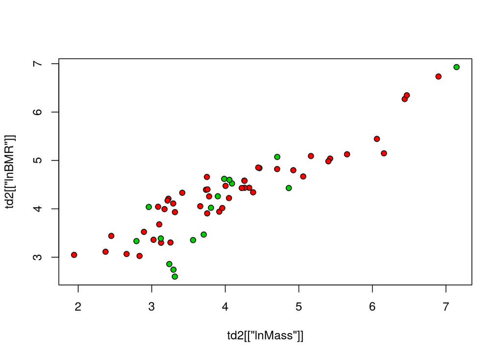

```r
plot(td2[['lnMass']], td2[['lnBMR']], pch=21, bg=td2[['desert']]+2)
```

## IV. Visualization

Ape plotting:

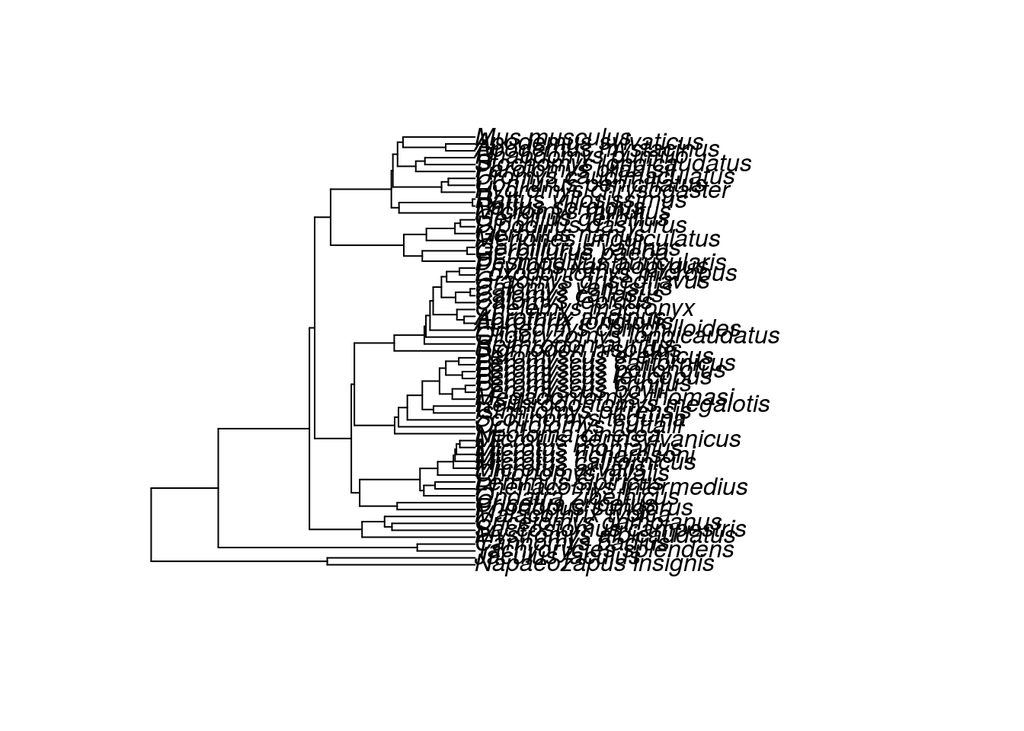

```r
tree <- td2$phy
dat <- td2$dat

plot(tree)
```

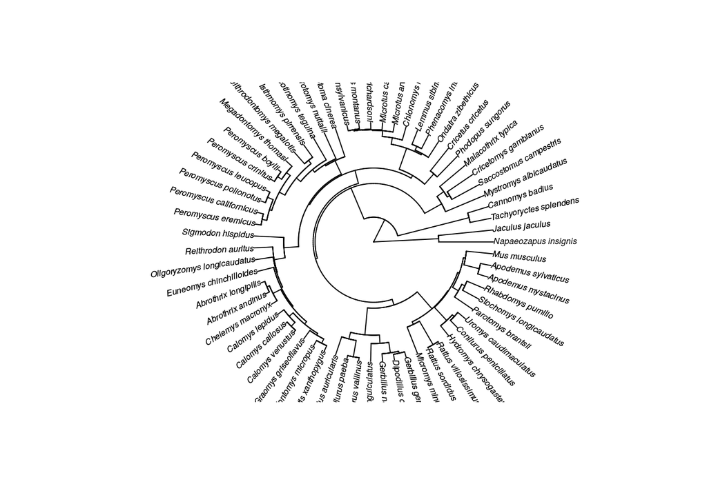

```r
plot(tree, type="fan", cex=0.5)
```

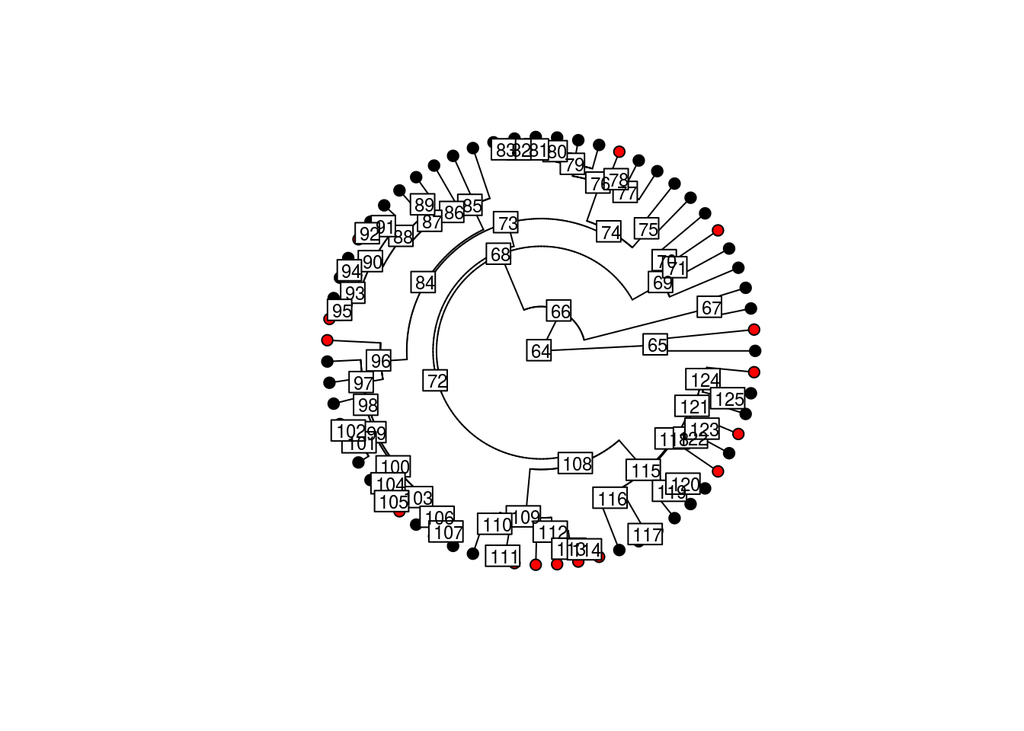

```r
plot(tree, type="fan", show.tip.label=FALSE)
tiplabels(pch=21, bg=dat$desert+1)
nodelabels(cex=0.75,bg="white" )
```

Plot a traitgram to visualize a continuous trait:

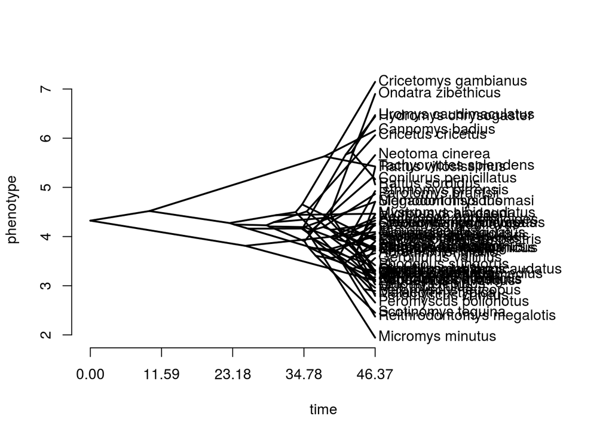

```r
require(phytools)
phenogram(tree, setNames(dat[['lnMass']], tree$tip.label), spread.labels=FALSE)
```

Another useful tool is to plot the contrasts vs. the node height of the tree:

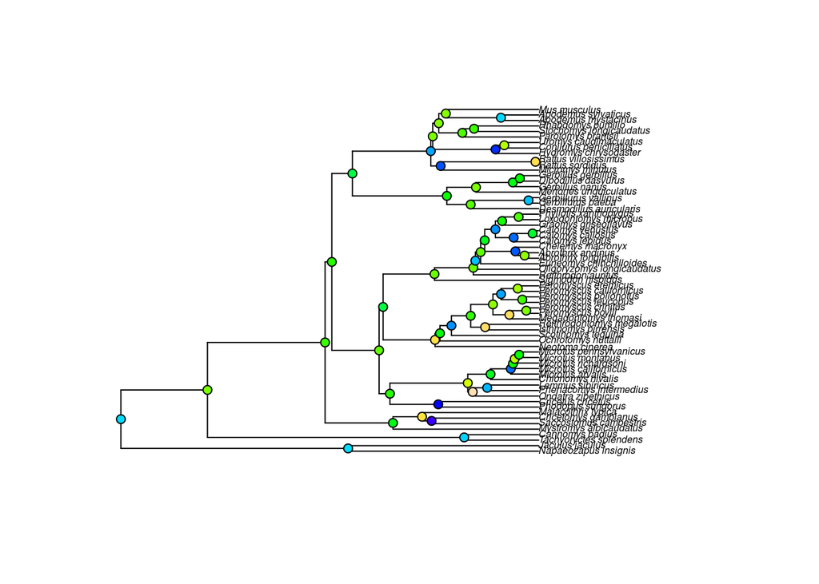

```r
picMass <- pic(dat$lnMass, tree)
plot(tree, cex=0.5)
nodelabels(pch=21, bg=topo.colors(100)[round((picMass-min(picMass))/diff(range(picMass))*100,0)])
```

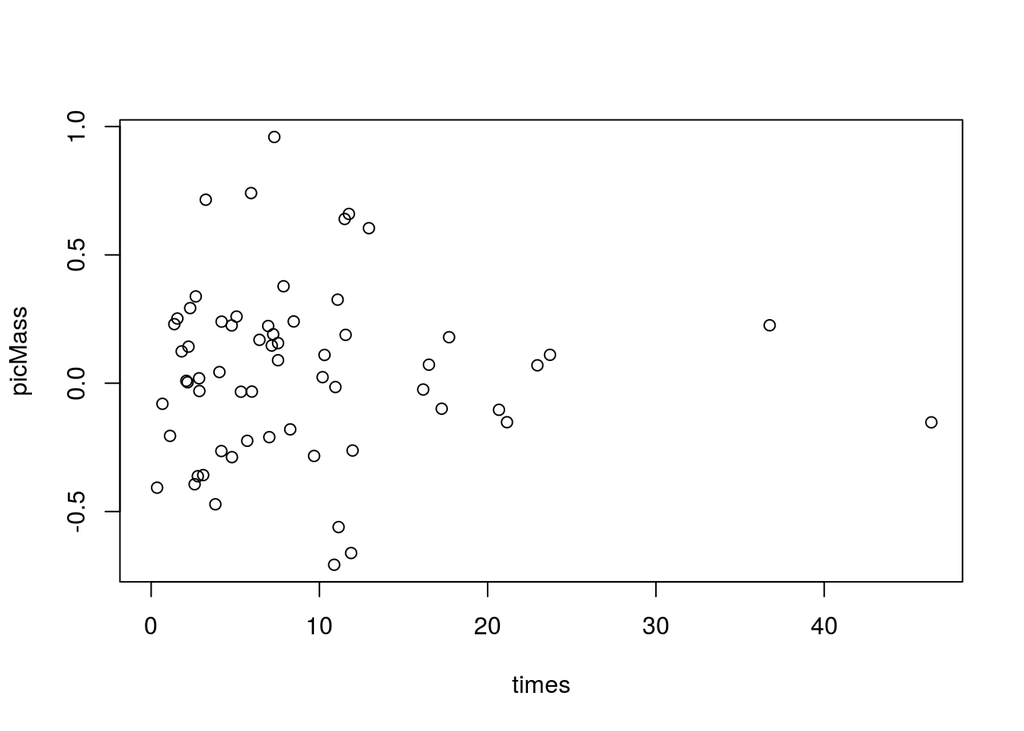

```r
times <- branching.times(tree)
plot(times, picMass, xlim=c(0, max(times)))
```

Phytools’ scattergram can be useful for exploring correlations between traits across the phylogeny:

```r
fancyDat <- as.matrix(dat[,1:3])
rownames(fancyDat) <- tree$tip.label
fancyTree(tree, type="scattergram", X=fancyDat, fsize=0.3)
```

```
## Computing multidimensional phylogenetic scatterplot matrix...
```

[figure not shown]

## V. Simple analyses of traits

### Discrete trait models

We generally use “continuous-time Markov models” to model discrete traits on the phylogeny. These models are used to model transitions between discrete character states, whether they are the presence/absence of phenotypic trait or nucleotide a specific site. We can fit such a model to a trait and a phylogeny using the `fitDiscrete` function in in `geiger`.

```r
tdDiscrete <- filter(td2, !is.na(desert))
trait <- setNames(tdDiscrete$dat$desert, tdDiscrete$phy$tip.label)+1
mER <- fitDiscrete(tdDiscrete$phy, trait, model="ER")
mARD <- fitDiscrete(tdDiscrete$phy, trait, model="ARD")
mER
```

```
## GEIGER-fitted comparative model of discrete data
##  fitted Q matrix:
##                 1           2
##     1 -0.03345339  0.03345339
##     2  0.03345339 -0.03345339
##
##  model summary:
##  log-likelihood = -36.111580
##  AIC = 74.223160
##  AICc = 74.288734
##  free parameters = 1
##
## Convergence diagnostics:
##  optimization iterations = 100
##  failed iterations = 0
##  frequency of best fit = 1.00
##
##  object summary:
##  'lik' -- likelihood function
##  'bnd' -- bounds for likelihood search
##  'res' -- optimization iteration summary
##  'opt' -- maximum likelihood parameter estimates
```

```r
mARD
```

```
## GEIGER-fitted comparative model of discrete data
##  fitted Q matrix:
##                 1           2
##     1 -0.05245159  0.05245159
##     2  0.14972482 -0.14972482
##
##  model summary:
##  log-likelihood = -33.922913
##  AIC = 71.845826
##  AICc = 72.045826
##  free parameters = 2
##
## Convergence diagnostics:
##  optimization iterations = 100
##  failed iterations = 0
##  frequency of best fit = 0.59
##
##  object summary:
##  'lik' -- likelihood function
##  'bnd' -- bounds for likelihood search
##  'res' -- optimization iteration summary
##  'opt' -- maximum likelihood parameter estimates
```

### Continuous trait models

For continuous traits, we generally use “Gaussian models” that result in multivariate normal distributions. The most basic and familiar of these is Brownian motion. We can fit a Brownian motion model using the function `fitContinuous` from the `geiger` package.

```r
trait <- setNames(dat$lnMass, tree$tip.label)
mBM <- fitContinuous(tree, trait, model="BM")
mBM
```

```
## GEIGER-fitted comparative model of continuous data
##  fitted 'BM' model parameters:
##  sigsq = 0.110338
##  z0 = 4.323551
##
##  model summary:
##  log-likelihood = -90.074247
##  AIC = 184.148495
##  AICc = 184.348495
##  free parameters = 2
##
## Convergence diagnostics:
##  optimization iterations = 100
##  failed iterations = 0
##  frequency of best fit = 1.00
##
##  object summary:
##  'lik' -- likelihood function
##  'bnd' -- bounds for likelihood search
##  'res' -- optimization iteration summary
##  'opt' -- maximum likelihood parameter estimates
```

An more general model than the Brownian motion model is the Ornstein-Uhlenbeck model, which has one additional parameter describing the central tendency of traits to evolve toward an intermediate optimum (think of a rubber band pulling back towards an optimum trait value).

```r
mOU <- fitContinuous(tree, trait, model="OU")
mBM
```

```
## GEIGER-fitted comparative model of continuous data
##  fitted 'BM' model parameters:
##  sigsq = 0.110338
##  z0 = 4.323551
##
##  model summary:
##  log-likelihood = -90.074247
##  AIC = 184.148495
##  AICc = 184.348495
##  free parameters = 2
##
## Convergence diagnostics:
##  optimization iterations = 100
##  failed iterations = 0
##  frequency of best fit = 1.00
##
##  object summary:
##  'lik' -- likelihood function
##  'bnd' -- bounds for likelihood search
##  'res' -- optimization iteration summary
##  'opt' -- maximum likelihood parameter estimates
```

Another model is one in which the rate of evolution is initially rapid, but slows over time. This is called the early-burst model (EB). Let’s fit all models simultaneously using first 1) a loop and then 2) the lapply function. This time, we’ll use the BMR data instead of the mass data:

```r
trait <- setNames(dat$lnBMR, tree$tip.label)
models <- c("BM", "OU", "EB")
mFits <- list()
for(i in 1:length(models)){
  mFits[[i]] <- fitContinuous(tree, trait, model=models[i])
}
#Above can also be accomplished by using lapply:
mFits <- lapply(1:length(models), function(i) fitContinuous(tree, trait, model=models[i]))
```

Model selection can be conducted by comparing AIC values:

```r
aiccs <- lapply(mFits, function(x) x$opt$aicc)
names(aiccs) <- models
aiccs
```

```
## $BM
## [1] 154.3445
##
## $OU
## [1] 150.447
##
## $EB
## [1] 156.5513
```

## VI. Getting a phylogeny from a list of taxa

Most comparative analyses require a time-calibrated phylogeny. The gold standard is to estimate this phylogeny from molecular sequence data, and time-calibrate the resulting phylogeny with fossil calibrations. However, some resources exist for drawing on existing phylogenetic and taxonomic information. One project spearheading the effort to synthesize existing phylogenetic knowledge is the OpenTree of Life (OTL) that has excellent API resources that can be used to obtain synthetic phylogenies, as well as other services such as taxonomic name resolution (this is huge, you will spend a huge amount of time dealing with names).

```r
library(rotl)
taxalist <- c("Picoides_borealis", "Carpodacus_mexicana", "Hyla_regilla", "Lithobates_catesbeiana", "Cambarincola", "Cambarus_chasmodactylus", "Pipra_filicauda", "Chrysopelia_paradisi", "Cyanobacteria", "Norops_sagrei", "Carollia_perspicillata", "Piper peltatum", "Taeniopygia_guttata", "Plethodon_hubrichti", "Felus_domestica", "Aedes_aegypti", "Plasmodium_vivax")
```

Let’s use OpenTree of Life’s powerful taxonomic name resolution services, which draws on NCBI, GBIF, Fishbase, and others to build a comprehensive taxonomy for all life.

```r
ottTable <- tnrs_match_names(taxalist)
ottTable
```

| search_string | unique_name | approximate_match | ott_id | is_synonym | flags | number_matches |
| --- | --- | --- | --- | --- | --- | --- |
| picoides_borealis | Picoides borealis | TRUE | 701708 | FALSE |  | 3 |
| carpodacus_mexicana | Haemorhous mexicanus | TRUE | 711865 | TRUE | SIBLING_HIGHER | 1 |
| hyla_regilla | Pseudacris regilla | TRUE | 1038213 | TRUE |  | 1 |
| lithobates_catesbeiana | Rana catesbeiana | TRUE | 14688 | TRUE |  | 2 |
| cambarincola | Cambarincola | FALSE | 251550 | FALSE | SIBLING_HIGHER | 1 |
| cambarus_chasmodactylus | Cambarus chasmodactylus | TRUE | 1048056 | FALSE |  | 1 |
| pipra_filicauda | Pipra filicauda | TRUE | 946233 | FALSE |  | 1 |
| chrysopelia_paradisi | Chrysopelea paradisi | TRUE | 564756 | FALSE |  | 2 |
| cyanobacteria | Cyanobacteria | FALSE | 225495 | FALSE | SIBLING_HIGHER | 1 |
| norops_sagrei | Anolis sagrei | TRUE | 970153 | TRUE | SIBLING_HIGHER | 2 |

[output cut: 7 more lines]

Now we can use the Open Tree Taxonomy (OTT) IDs to obtain a synthetic tree of only those taxa.

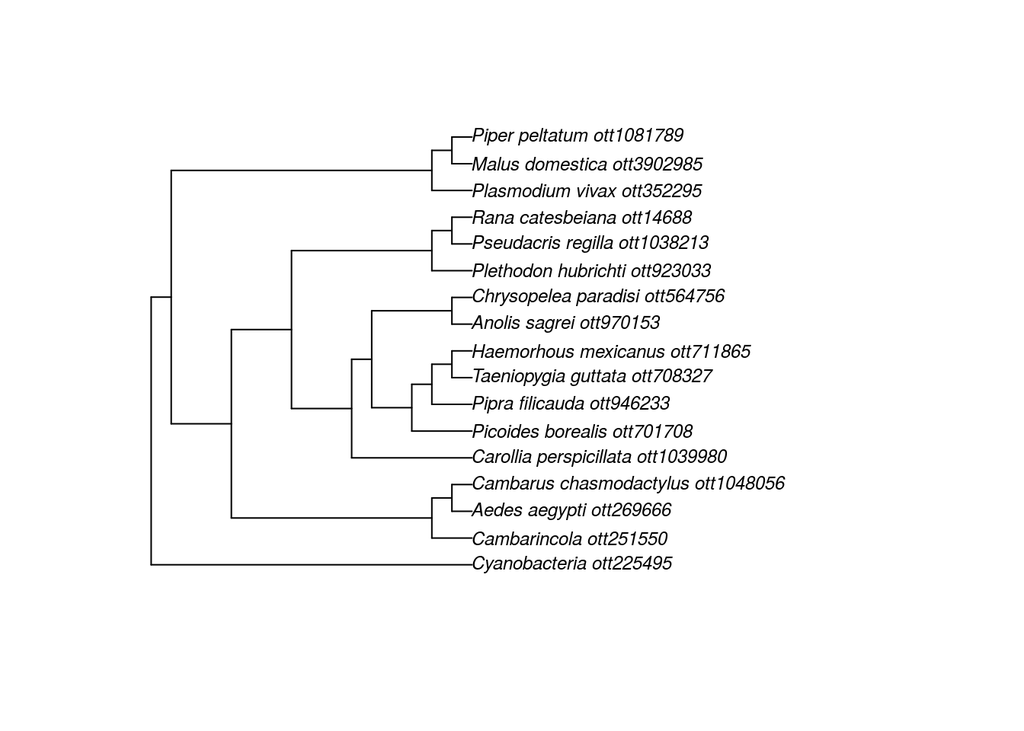

```r
synth_tree <- tol_induced_subtree(ottTable$ott_id)
plot(synth_tree, cex=0.75)
```

Unfortunately, trees from OpenTree do not have branch lengths. The package datelife is in active development to remedy this.

```r
devtools::install_github("phylotastic/datelife")
library(datelife)
```

```r
taxa <- gsub(" ", "_", ottTable$unique_name)
datelife_result <- datelife::datelife_search(taxa)
```

```
## Source chronograms from:
## [1] Yuchi Zheng, John J. Wiens, 2016, 'Combining phylogenomic and supermatrix approaches, and a time-calibrated phylogeny for squamate reptiles (lizards and snakes) based on 52 genes and 4162 species', Molecular Phylogenetics and Evolution, vol. 94, pp. 537-547
## [2] Pyron, R. Alexander, Frank T. Burbrink. 2013. Early origin of viviparity and multiple reversions to oviparity in squamate reptiles. Ecology Letters 17 (1): 13-21
## [3] Hooper, Daniel M., Trevor D. Price. 2017. Chromosomal inversion differences correlate with range overlap in passerine birds. Nature Ecology & Evolution 1 (10): 1526-1534
## [4] Wright, April M., Kathleen M. Lyons, Matthew C. Brandley, David M. Hillis. 2015. Which came first: The lizard or the egg? Robustness in phylogenetic reconstruction of ancestral states. Journal of Experimental Zoology Part B: Molecular and Developmental Evolution 324 (6): 504-516
## [5] Hedges, S. Blair, Julie Marin, Michael Suleski, Madeline Paymer, Sudhir Kumar. 2015. Tree of life reveals clock-like speciation and diversification. Molecular Biology and Evolution 32 (4): 835-845
## [6] Hedges, S. Blair, Julie Marin, Michael Suleski, Madeline Paymer, Sudhir Kumar. 2015. Tree of life reveals clock-like speciation and diversification. Molecular Biology and Evolution 32 (4): 835-845
## [7] Jetz, W., G. H. Thomas, J. B. Joy, K. Hartmann, A. O. Mooers. 2012. The global diversity of birds in space and time. Nature 491 (7424): 444-448
## [8] Jetz, W., G. H. Thomas, J. B. Joy, K. Hartmann, A. O. Mooers. 2012. The global diversity of birds in space and time. Nature 491 (7424): 444-448
##
## Target taxa presence in source chronograms:
##                     Taxon Chronograms
## 1           Anolis sagrei         4/8
## 2    Chrysopelea paradisi         4/8
## 3     Taeniopygia guttata         5/8
```

[output cut: 17 more lines]

```r
datelife_result
```

```
## $...
##
## Phylogenetic tree with 2 tips and 1 internal nodes.
##
## Tip labels:
## [1] "Chrysopelea paradisi" "Anolis sagrei"
##
## Rooted; includes branch lengths.
##
## $`Pyron, R. Alexander, Frank T. Burbrink. 2013. Early origin of viviparity and multiple reversions to oviparity in squamate reptiles. Ecology Letters 17 (1): 13-21`
##
## Phylogenetic tree with 2 tips and 1 internal nodes.
##
## Tip labels:
## [1] "Anolis sagrei"        "Chrysopelea paradisi"
##
## Rooted; includes branch lengths.
##
## $`Hooper, Daniel M., Trevor D. Price. 2017. Chromosomal inversion differences correlate with range overlap in passerine birds. Nature Ecology & Evolution 1 (10): 1526-1534`
##
## Phylogenetic tree with 2 tips and 1 internal nodes.
##
## Tip labels:
## [1] "Taeniopygia guttata"  "Haemorhous mexicanus"
##
## Rooted; includes branch lengths.
##
## $...
##
## Phylogenetic tree with 2 tips and 1 internal nodes.
##
## Tip labels:
## [1] "Chrysopelea paradisi" "Anolis sagrei"
##
## Rooted; includes branch lengths.
##
## $`Hedges, S. Blair, Julie Marin, Michael Suleski, Madeline Paymer, Sudhir Kumar. 2015. Tree of life reveals clock-like speciation and diversification. Molecular Biology and Evolution 32 (4): 835-845`
##
## Phylogenetic tree with 12 tips and 11 internal nodes.
##
```

[output cut: 18 more lines]

```
## Tip labels:
## [1] "Pipra filicauda"      "Haemorhous mexicanus" "Taeniopygia guttata"
## [4] "Picoides borealis"
##
## Rooted; includes branch lengths.
##
## $`Jetz, W., G. H. Thomas, J. B. Joy, K. Hartmann, A. O. Mooers. 2012. The global diversity of birds in space and time. Nature 491 (7424): 444-448`
##
## Phylogenetic tree with 4 tips and 3 internal nodes.
##
## Tip labels:
## [1] "Picoides borealis"    "Pipra filicauda"      "Taeniopygia guttata"
## [4] "Haemorhous mexicanus"
##
## Rooted; includes branch lengths.
```

## Questions & exercises:

1. If you have phylogenetic signal in the trait of interest, that means you MUST USE a phylogenetic regression method (e.g. PGLS, PICs) to analyze the trait. Explain (Hint: Look up the assumptions of Ordinary Least Squares regression).
2. You conduct model selection using fitContinuous and find that the OU model is a better fit to trait evolution over BM. You should prefer an OU correlation structure for any PGLS model you fit. Why or why not?
3. Each of the following lines of code produces an error. Fix the error to accomplish the task requested.
1. Fit a BM model using fitContinuous

```r
ex3a <- readRDS("../data/ex3a.rds")
phy <- ex3a$tree
trait <- ex3a$dat
try(fitContinuous(phy, trait, model="BM"))
```

2. Plot a phenogram of the data

```r
ex3b <- readRDS("../data/ex3b.rds")
phy <- ex3b$tree
trait <- ex3b$dat
try(phenogram(phy, trait[,1], spread.labels=FALSE))
```

4. Below we have a dataset of 23 species of Icterus (New World Orioles) and a posterior distribution of phylogenies from www.birdtree.org based on genetic sequence data (Hackett backbone). Fit a Brownian motion model to each tree for Tarsus length, save all the results as a list, and extract the estimate of the sigma^2 parameter. Plot a histogram of that parameter.

```r
icterus <-  read.table("../data/icterus.dat", header=TRUE, sep="\t")
icterus.trees <- read.nexus("../data/icterus.tre")

icterus.trees
```

```
## 100 phylogenetic trees
```

```r
BMfitter <- function(i){
  ## Fill this in with code to A) match tree and data B) select Tarsus as the dataset C) perform a fitContinuous fit
  ## and D) return the fitted object
}
```

Use a loop or an lapply call to call the `BMfitter` function for all values of i from 1 to 100

Use sapply to extract all the estimates of the parameter `sigsq`

Plot the resulting vector of sigma^2 estimates.